# lab10-FML_NP

Name-Nisarg Patel student id-8878184

Obtain the Data

-Download the BIRDS 525 SPECIES dataset from Kaggle (CC0 license). You will need to create a free Kaggle account, and this will provide you free access to many such datasets, as well as code and even online notebooks.

-Unpack the data. Notice that the data is organized into folders in a way similar to the Dogs vs Cats dataset that we worked with. This makes it easy to load with the same Keras function (ImageDataGenerator.flow_from_directory).

-For this lab, we will work with the 3 classes with the highest number of images. Identify those classes, and use only these for the next steps. You can delete/discard the others.

-Use data-augmentation to increase the number of training images. You are encouraged to try out various augmentation methods supported by Keras. The rule of thumb is that as long as an augmentation produces realistic images - it is probably a good idea to add it.(2 point)

-Fine-Tune VGG16 (pre-trained on imagenet), to classify the 3 classes (2 points)

-Explore the model performance: accuracy, confusion metric, precision, recall, F1-score, precision-recall curve and its area under the curve (AUC). Explore specific examples in which the model failed to predict correctly. (2 points)

```python
from tensorflow import keras
from tensorflow.keras import layers
import pathlib
from tensorflow.keras.utils import image_dataset_from_directory
```

```python
# Specify the path to your dataset
data_dir = r'C:\Users\nisar\Downloads\archive'
```

```python
conv_base = keras.applications.vgg16.VGG16(
    weights="imagenet",
    include_top=False,
    input_shape=(180, 180, 3))
```

```
Downloading data from https://storage.googleapis.com/tensorflow/keras-applications/vgg16/vgg16_weights_tf_dim_ordering_tf_kernels_notop.h5
```

```python
conv_base.summary()
```

```
Model: "vgg16"
_________________________________________________________________
 Layer (type)                Output Shape              Param #
=================================================================
 input_1 (InputLayer)        [(None, 180, 180, 3)]     0

 block1_conv1 (Conv2D)       (None, 180, 180, 64)      1792

 block1_conv2 (Conv2D)       (None, 180, 180, 64)      36928

 block1_pool (MaxPooling2D)  (None, 90, 90, 64)        0

 block2_conv1 (Conv2D)       (None, 90, 90, 128)       73856

 block2_conv2 (Conv2D)       (None, 90, 90, 128)       147584

 block2_pool (MaxPooling2D)  (None, 45, 45, 128)       0

 block3_conv1 (Conv2D)       (None, 45, 45, 256)       295168

 block3_conv2 (Conv2D)       (None, 45, 45, 256)       590080

 block3_conv3 (Conv2D)       (None, 45, 45, 256)       590080

 block3_pool (MaxPooling2D)  (None, 22, 22, 256)       0

 block4_conv1 (Conv2D)       (None, 22, 22, 512)       1180160

 block4_conv2 (Conv2D)       (None, 22, 22, 512)       2359808

 block4_conv3 (Conv2D)       (None, 22, 22, 512)       2359808

 block4_pool (MaxPooling2D)  (None, 11, 11, 512)       0

 block5_conv1 (Conv2D)       (None, 11, 11, 512)       2359808

 block5_conv2 (Conv2D)       (None, 11, 11, 512)       2359808

 block5_conv3 (Conv2D)       (None, 11, 11, 512)       2359808

 block5_pool (MaxPooling2D)  (None, 5, 5, 512)         0

=================================================================
Total params: 14714688 (56.13 MB)
Trainable params: 14714688 (56.13 MB)
Non-trainable params: 0 (0.00 Byte)
_________________________________________________________________
```

```python
from tensorflow.keras.preprocessing.image import ImageDataGenerator

# Create an ImageDataGenerator with data augmentation
datagen = ImageDataGenerator(
    rescale=1./255,
    rotation_range=20,
    width_shift_range=0.2,
    height_shift_range=0.2,
    shear_range=0.2,
    zoom_range=0.2,
    horizontal_flip=True,
    fill_mode='nearest'
)

# Create a flow_from_directory generator for training data
train_generator = datagen.flow_from_directory(
    data_dir,
    target_size=(224, 224),
    batch_size=32,
    class_mode='categorical',
    shuffle=True
)
```

```
Found 89885 images belonging to 3 classes.
```

```python
from pathlib import Path

# Define the path to the CSV file
csv_file_path = pathlib.Path("./birds.csv")

train_directory = Path("./train")
```

```python
from tensorflow.keras.preprocessing.image import ImageDataGenerator

# Define image size, batch size, and class mode
image_size = (224, 224)
batch_size = 32
class_mode = 'categorical'

# Create an ImageDataGenerator instance
data_gen = ImageDataGenerator(rescale=1./255)

# Define the full path to the training, validation, and test directories
train_data_path = r"C:\Users\nisar\Downloads\archive\train"
valid_data_path = r"C:\Users\nisar\Downloads\archive\valid"
test_data_path = r"C:\Users\nisar\Downloads\archive\test"

# Use flow_from_directory to load and preprocess images
train_data = data_gen.flow_from_directory(
    train_data_path,
    target_size=image_size,
    batch_size=batch_size,
    class_mode=class_mode
)

validation_data = data_gen.flow_from_directory(
    valid_data_path,
    target_size=image_size,
    batch_size=batch_size,
    class_mode=class_mode
)

test_data = data_gen.flow_from_directory(
    test_data_path,
    target_size=image_size,
    batch_size=batch_size,
    class_mode=class_mode,
    shuffle=False
)
```

```
Found 84635 images belonging to 525 classes.
Found 2625 images belonging to 525 classes.
Found 2625 images belonging to 525 classes.
```

```python
from collections import Counter
from pathlib import Path
from keras.preprocessing.image import ImageDataGenerator

# Function to get the top N classes with the highest number of images
def get_top_classes(dataset_path, top_n=3):
    class_counts = Counter()
    dataset_path = Path(dataset_path)

    # Iterate through class folders and count images
    for class_folder in dataset_path.iterdir():
        if class_folder.is_dir():
            class_name = class_folder.name
            image_count = len(list(class_folder.glob('*')))
            class_counts[class_name] = image_count

    # Get top N classes
    top_classes = dict(class_counts.most_common(top_n))
    return top_classes

# Define the path to the main dataset folder
dataset_path = r"C:\Users\nisar\Downloads\archive\train"

# Get the top three classes with the highest number of images
top_classes = get_top_classes(dataset_path, top_n=3)

# Display the top classes and their image counts
print("Top Classes:")
for class_name, image_count in top_classes.items():
    print(f"{class_name}: {image_count} images")

# Define data augmentation and preprocessing settings
train_datagen = ImageDataGenerator(
    rescale=1.0/255,
    rotation_range=20,
    width_shift_range=0.2,
    height_shift_range=0.2,
    horizontal_flip=True
)

# Load images from the selected classes
selected_classes = list(top_classes.keys())
train_generator = train_datagen.flow_from_directory(
    dataset_path,
    classes=selected_classes,
    target_size=(150, 150),
    batch_size=32,
    class_mode='categorical'
)
```

```
Top Classes:
RUFOUS TREPE: 263 images
HOUSE FINCH: 248 images
D-ARNAUDS BARBET: 233 images
Found 744 images belonging to 3 classes.
```

```python
import os
import shutil

# Define the paths to the train, test, and valid folders
train_folder = r"C:\Users\nisar\Downloads\archive\train"
test_folder = r"C:\Users\nisar\Downloads\archive\test"
valid_folder = r"C:\Users\nisar\Downloads\archive\valid"

# Get the top 3 classes
top_classes = get_top_classes(train_folder, top_n=3)
top3_class = list(top_classes.keys())

# Delete directories in the train folder
for species in os.listdir(train_folder):
    if species not in top3_class:
        delete_path_train = os.path.join(train_folder, species)
        shutil.rmtree(delete_path_train)

# Delete directories in the test folder
for species in os.listdir(test_folder):
    if species not in top3_class:
        delete_path_test = os.path.join(test_folder, species)
        shutil.rmtree(delete_path_test)

# Delete directories in the valid folder
for species in os.listdir(valid_folder):
    if species not in top3_class:
        delete_path_valid = os.path.join(valid_folder, species)
        shutil.rmtree(delete_path_valid)
```

```python
from keras.preprocessing.image import ImageDataGenerator

# Define the paths to the train, test, and valid folders
train_folder = r"C:\Users\nisar\Downloads\archive\train"
test_folder = r"C:\Users\nisar\Downloads\archive\test"
valid_folder = r"C:\Users\nisar\Downloads\archive\valid"

# Define image size, batch size, and class mode
image_size = (224, 224)
batch_size = 32
class_mode = 'categorical'

# Create an instance of ImageDataGenerator with augmentation options
datagen = ImageDataGenerator(
    rotation_range=20,
    width_shift_range=0.2,
    height_shift_range=0.2,
    shear_range=0.2,
    zoom_range=0.2,
    horizontal_flip=True,
    fill_mode='nearest'
)

# Load and augment images using flow_from_directory for training
train_generator = datagen.flow_from_directory(
    train_folder,
    target_size=image_size,
    batch_size=batch_size,
    class_mode=class_mode
)

# Load and augment images using flow_from_directory for testing
test_generator = datagen.flow_from_directory(
    test_folder,
    target_size=image_size,
    batch_size=batch_size,
    class_mode=class_mode
)

# Load and augment images using flow_from_directory for validation
valid_generator = datagen.flow_from_directory(
    valid_folder,
    target_size=image_size,
    batch_size=batch_size,
    class_mode=class_mode
)
```

```
Found 744 images belonging to 3 classes.
Found 15 images belonging to 3 classes.
Found 15 images belonging to 3 classes.
```

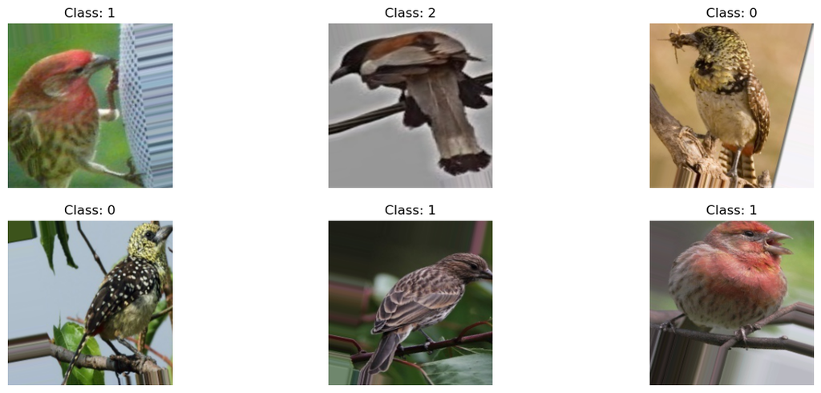

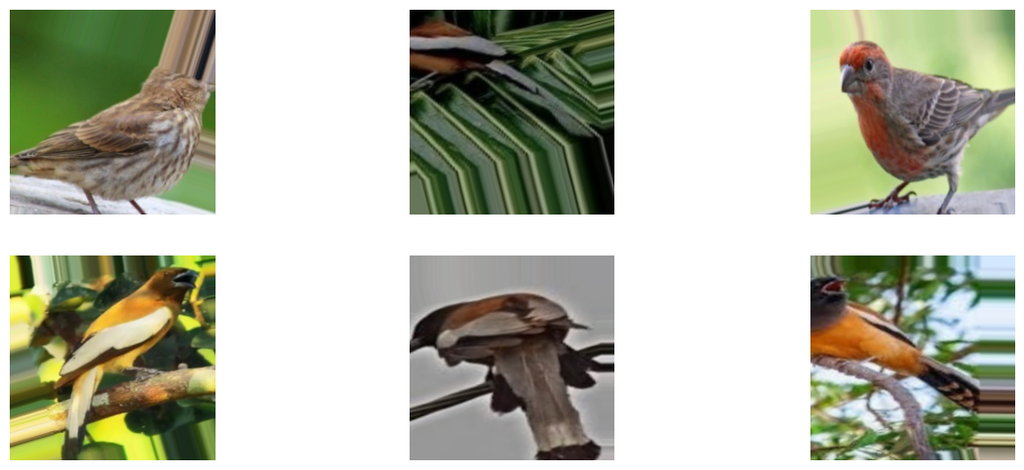

```python
import matplotlib.pyplot as plt
from tensorflow.keras.preprocessing.image import ImageDataGenerator

# Create an ImageDataGenerator with augmentation settings
datagen = ImageDataGenerator(
    rotation_range=20,
    width_shift_range=0.2,
    height_shift_range=0.2,
    shear_range=0.2,
    horizontal_flip=True,
    fill_mode='nearest'
)

# Choose a batch of images and labels from the train_generator
batch_size = 6  # Number of original images to display

# Load a batch of images from the generator
images, labels = next(train_generator)

# Display original images
plt.figure(figsize=(15, 6))
for i in range(batch_size):
    ax = plt.subplot(2, 3, i + 1)
    plt.imshow(images[i].astype("uint8"))
    plt.title(f"Class: {labels[i].argmax()}")
    plt.axis("off")

# Generate and display augmented images
augmented_images = datagen.flow(images, batch_size=batch_size)
augmented_images = next(augmented_images)

plt.figure(figsize=(15, 6))
for i in range(batch_size):
    ax = plt.subplot(2, 3, i + 1)
    plt.imshow(augmented_images[i].astype("uint8"))
    plt.axis("off")

plt.show()
```

```python
from tensorflow.keras.applications import VGG16

# Load the VGG16 model pre-trained on ImageNet data
base_model = VGG16(weights='imagenet', include_top=False, input_shape=(224, 224, 3))

# Freeze the pre-trained layers to prevent training
for layer in base_model.layers:
    layer.trainable = False

# Check the summary of the loaded model
base_model.summary()
```

```
Model: "vgg16"
_________________________________________________________________
 Layer (type)                Output Shape              Param #
=================================================================
 input_2 (InputLayer)        [(None, 224, 224, 3)]     0

 block1_conv1 (Conv2D)       (None, 224, 224, 64)      1792

 block1_conv2 (Conv2D)       (None, 224, 224, 64)      36928

 block1_pool (MaxPooling2D)  (None, 112, 112, 64)      0

 block2_conv1 (Conv2D)       (None, 112, 112, 128)     73856

 block2_conv2 (Conv2D)       (None, 112, 112, 128)     147584

 block2_pool (MaxPooling2D)  (None, 56, 56, 128)       0

 block3_conv1 (Conv2D)       (None, 56, 56, 256)       295168

 block3_conv2 (Conv2D)       (None, 56, 56, 256)       590080

 block3_conv3 (Conv2D)       (None, 56, 56, 256)       590080

 block3_pool (MaxPooling2D)  (None, 28, 28, 256)       0

 block4_conv1 (Conv2D)       (None, 28, 28, 512)       1180160

 block4_conv2 (Conv2D)       (None, 28, 28, 512)       2359808

 block4_conv3 (Conv2D)       (None, 28, 28, 512)       2359808

 block4_pool (MaxPooling2D)  (None, 14, 14, 512)       0

 block5_conv1 (Conv2D)       (None, 14, 14, 512)       2359808

 block5_conv2 (Conv2D)       (None, 14, 14, 512)       2359808

 block5_conv3 (Conv2D)       (None, 14, 14, 512)       2359808

 block5_pool (MaxPooling2D)  (None, 7, 7, 512)         0

=================================================================
Total params: 14714688 (56.13 MB)
Trainable params: 0 (0.00 Byte)
Non-trainable params: 14714688 (56.13 MB)
_________________________________________________________________
```

```python
from tensorflow.keras import layers, Model

# Assuming you have already loaded the VGG16 base_model
base_model = VGG16(weights='imagenet', include_top=False, input_shape=(224, 224, 3))

# Freeze some layers of the base model
for layer in base_model.layers:
    layer.trainable = False

# Add custom layers for classification
x = base_model.output
x = layers.GlobalAveragePooling2D()(x)
x = layers.Dense(128, activation='relu')(x)
x = layers.Dropout(0.5)(x)
predictions = layers.Dense(3, activation='softmax')(x)  # Assuming 3 classes, adjust as needed

# Create the fine-tuned model
model = Model(inputs=base_model.input, outputs=predictions)

# Compile the model
model.compile(
    optimizer='adam',
    loss='categorical_crossentropy',
    metrics=['accuracy']
)

# Check the summary of the complete model
model.summary()
```

```
Model: "model"
_________________________________________________________________
 Layer (type)                Output Shape              Param #
=================================================================
 input_3 (InputLayer)        [(None, 224, 224, 3)]     0

 block1_conv1 (Conv2D)       (None, 224, 224, 64)      1792

 block1_conv2 (Conv2D)       (None, 224, 224, 64)      36928

 block1_pool (MaxPooling2D)  (None, 112, 112, 64)      0

 block2_conv1 (Conv2D)       (None, 112, 112, 128)     73856

 block2_conv2 (Conv2D)       (None, 112, 112, 128)     147584

 block2_pool (MaxPooling2D)  (None, 56, 56, 128)       0

 block3_conv1 (Conv2D)       (None, 56, 56, 256)       295168

 block3_conv2 (Conv2D)       (None, 56, 56, 256)       590080

 block3_conv3 (Conv2D)       (None, 56, 56, 256)       590080

 block3_pool (MaxPooling2D)  (None, 28, 28, 256)       0

 block4_conv1 (Conv2D)       (None, 28, 28, 512)       1180160

 block4_conv2 (Conv2D)       (None, 28, 28, 512)       2359808

 block4_conv3 (Conv2D)       (None, 28, 28, 512)       2359808

 block4_pool (MaxPooling2D)  (None, 14, 14, 512)       0

 block5_conv1 (Conv2D)       (None, 14, 14, 512)       2359808

 block5_conv2 (Conv2D)       (None, 14, 14, 512)       2359808

 block5_conv3 (Conv2D)       (None, 14, 14, 512)       2359808

 block5_pool (MaxPooling2D)  (None, 7, 7, 512)         0

 global_average_pooling2d (  (None, 512)               0
 GlobalAveragePooling2D)

 dense (Dense)               (None, 128)               65664

 dropout (Dropout)           (None, 128)               0

 dense_1 (Dense)             (None, 3)                 387

=================================================================
Total params: 14780739 (56.38 MB)
Trainable params: 66051 (258.01 KB)
Non-trainable params: 14714688 (56.13 MB)
_________________________________________________________________
```

```python
from tensorflow.keras.optimizers import Adam

# Assuming you have already loaded the VGG16 base_model
base_model = VGG16(weights='imagenet', include_top=False, input_shape=(224, 224, 3))

# Freeze all layers of the pretrained model for fine-tuning
base_model.trainable = False

# Add custom layers for classification
x = base_model.output
x = layers.GlobalAveragePooling2D()(x)
x = layers.Dense(128, activation='relu')(x)
x = layers.Dropout(0.5)(x)
predictions = layers.Dense(3, activation='softmax')(x)  # Assuming 3 classes, adjust as needed

# Create the fine-tuned model
model = Model(inputs=base_model.input, outputs=predictions)

# Compile the model with the Adam optimizer
model.compile(
    optimizer=Adam(),  # Using the Adam optimizer
    loss='categorical_crossentropy',
    metrics=['accuracy']
)

# Check the summary of the complete model
model.summary()
```

```
Model: "model_1"
_________________________________________________________________
 Layer (type)                Output Shape              Param #
=================================================================
 input_4 (InputLayer)        [(None, 224, 224, 3)]     0

 block1_conv1 (Conv2D)       (None, 224, 224, 64)      1792

 block1_conv2 (Conv2D)       (None, 224, 224, 64)      36928

 block1_pool (MaxPooling2D)  (None, 112, 112, 64)      0

 block2_conv1 (Conv2D)       (None, 112, 112, 128)     73856

 block2_conv2 (Conv2D)       (None, 112, 112, 128)     147584

 block2_pool (MaxPooling2D)  (None, 56, 56, 128)       0

 block3_conv1 (Conv2D)       (None, 56, 56, 256)       295168

 block3_conv2 (Conv2D)       (None, 56, 56, 256)       590080

 block3_conv3 (Conv2D)       (None, 56, 56, 256)       590080

 block3_pool (MaxPooling2D)  (None, 28, 28, 256)       0

 block4_conv1 (Conv2D)       (None, 28, 28, 512)       1180160

 block4_conv2 (Conv2D)       (None, 28, 28, 512)       2359808

 block4_conv3 (Conv2D)       (None, 28, 28, 512)       2359808

 block4_pool (MaxPooling2D)  (None, 14, 14, 512)       0

 block5_conv1 (Conv2D)       (None, 14, 14, 512)       2359808

 block5_conv2 (Conv2D)       (None, 14, 14, 512)       2359808

 block5_conv3 (Conv2D)       (None, 14, 14, 512)       2359808

 block5_pool (MaxPooling2D)  (None, 7, 7, 512)         0

 global_average_pooling2d_1  (None, 512)               0
  (GlobalAveragePooling2D)

 dense_2 (Dense)             (None, 128)               65664

 dropout_1 (Dropout)         (None, 128)               0

 dense_3 (Dense)             (None, 3)                 387

=================================================================
Total params: 14780739 (56.38 MB)
Trainable params: 66051 (258.01 KB)
Non-trainable params: 14714688 (56.13 MB)
_________________________________________________________________
```

```python
from tensorflow.keras.preprocessing.image import ImageDataGenerator

# Create an ImageDataGenerator for data augmentation
datagen = ImageDataGenerator(
    rescale=1.0 / 255,
    rotation_range=20,
    width_shift_range=0.2,
    height_shift_range=0.2,
    shear_range=0.2,
    zoom_range=0.2,
    horizontal_flip=True,
    fill_mode='nearest'
)

# Specify batch size and target image size
batch_size = 32
image_size = (224, 224)

# Create train and validation generators
train_generator = datagen.flow_from_directory(
    train_folder,
    target_size=image_size,
    batch_size=batch_size,
    class_mode='categorical'
)

validation_generator = datagen.flow_from_directory(
    valid_folder,
    target_size=image_size,
    batch_size=batch_size,
    class_mode='categorical'
)

# Train the model
history = model.fit(
    train_generator,
    steps_per_epoch=train_generator.samples // batch_size,
    epochs=10,
    validation_data=validation_generator
)
```

[output not shown]

```
Found 744 images belonging to 3 classes.
Found 15 images belonging to 3 classes.
```

```python
# Create a test generator
test_generator = datagen.flow_from_directory(
    test_folder,
    target_size=image_size,
    batch_size=batch_size,
    class_mode='categorical'
)

# Evaluate the model on the test set
test_loss, test_accuracy = model.evaluate(test_generator)
print(f'Test accuracy: {test_accuracy}')

# Save the fine-tuned model
model.save('fine_tuned_model.h5')
```

```
Found 15 images belonging to 3 classes.
Test accuracy: 1.0
```

```python
from sklearn.metrics import confusion_matrix, classification_report
import numpy as np
import matplotlib.pyplot as plt


# Evaluate the model on the test set
test_loss, test_accuracy = model.evaluate(test_generator)
print(f'Test accuracy: {test_accuracy}')

# Predict labels for the test set
y_pred = model.predict(test_generator)

# Convert predicted probabilities to class labels
y_pred_classes = np.argmax(y_pred, axis=1)
y_true_classes = test_generator.classes

# Confusion Matrix
conf_matrix = confusion_matrix(y_true_classes, y_pred_classes)
print("Confusion Matrix:")
print(conf_matrix)

# Classification Report
print("Classification Report:")
print(classification_report(y_true_classes, y_pred_classes, target_names=test_generator.class_indices.keys()))

# Analyze specific examples where the model failed
incorrectly_predicted_indices = (y_pred_classes != y_true_classes).nonzero()[0]

# Visualize a few examples where the model failed
for idx in incorrectly_predicted_indices[:5]:
    img_path = test_generator.filepaths[idx]
    true_class = test_generator.classes[idx]
    predicted_class = y_pred_classes[idx]

    # Display image, true class, and predicted class
    print(f"True class: {true_class}, Predicted class: {predicted_class}")
```

```
Test accuracy: 1.0
Confusion Matrix:
[[2 2 1]
 [2 1 2]
 [1 2 2]]
Classification Report:
                  precision    recall  f1-score   support

D-ARNAUDS BARBET       0.40      0.40      0.40         5
     HOUSE FINCH       0.20      0.20      0.20         5
    RUFOUS TREPE       0.40      0.40      0.40         5

        accuracy                           0.33        15
       macro avg       0.33      0.33      0.33        15
    weighted avg       0.33      0.33      0.33        15

True class: 0, Predicted class: 2
True class: 0, Predicted class: 1
True class: 0, Predicted class: 1
True class: 1, Predicted class: 0
True class: 1, Predicted class: 2
```

```python
from sklearn.metrics import roc_auc_score
import numpy as np

class_labels = ["Class1", "Class2", "Class3"]  # Replace with your actual class labels


# Predict labels for the test set
y_pred = model.predict(test_generator)

# Convert true classes to binary labels for each class
binary_labels = np.zeros_like(y_pred)
for i in range(len(class_labels)):
    binary_labels[:, i] = (test_generator.classes == i)

# Calculate AUC for each class
auc_scores = []
for i in range(len(class_labels)):
    auc_score = roc_auc_score(binary_labels[:, i], y_pred[:, i])
    auc_scores.append(auc_score)
    print("AUC for {}: {}".format(class_labels[i], auc_score))
```

```
AUC for Class1: 0.44000000000000006
AUC for Class2: 0.2
AUC for Class3: 0.56
```

```
Predicted: Class3, Actual: Class1
```

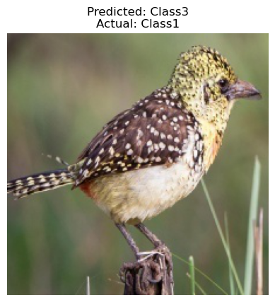

```
Predicted: Class2, Actual: Class1
```

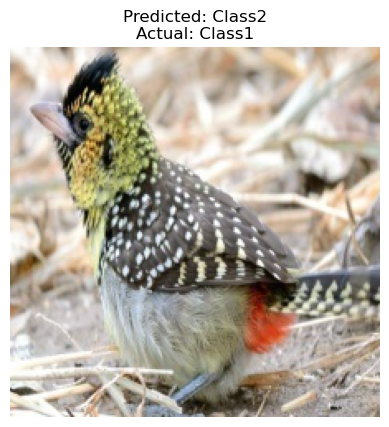

```
Predicted: Class2, Actual: Class1
```

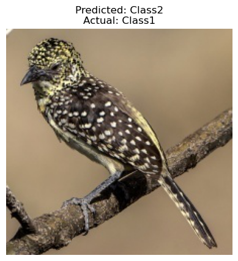

```
Predicted: Class1, Actual: Class2
```

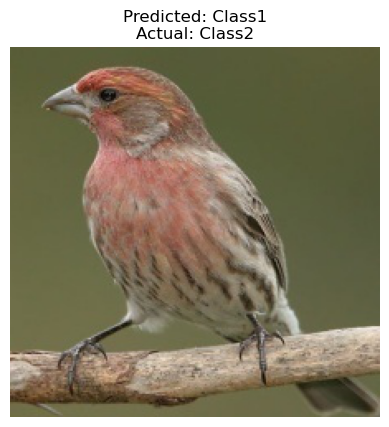

```
Predicted: Class3, Actual: Class2
```

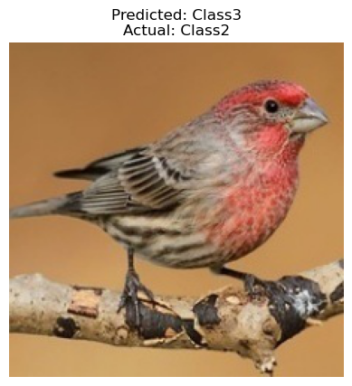

```python
misclassified_indexes = np.where(y_pred_classes != y_true_classes)[0]

for index in misclassified_indexes[:5]:  # Display first 5 misclassified examples
    predicted_class = class_labels[y_pred_classes[index]]
    actual_class = class_labels[y_true_classes[index]]

    print(f"Predicted: {predicted_class}, Actual: {actual_class}")

    # Load and display the misclassified image using matplotlib or any other library
    img_path = test_generator.filepaths[index]
    img = plt.imread(img_path)

    plt.imshow(img)
    plt.title(f"Predicted: {predicted_class}\nActual: {actual_class}")
    plt.axis("off")
    plt.show()
```